# WGCNA UN

WGCNA analysis of UN gene expression in B. rapa RILs.

Please see the CR notebook or RMD document for a brief description of what WGCNA is doing along with links where you can learn more.

```r
library(tidyverse)
library(WGCNA)
library(ggplot2)
library(edgeR)
library(magrittr)
library(gplots)
options(stringsAsFactors = FALSE)
```

Get data

```r
#box_load(162362592785)
load("~/Box Sync/BrapaNetworks/Voom_CR_UN.Rdata")
annotation  <- read.csv("~/Box Sync/BrapaNetworks/Brapa_V1.5_annotated.csv.gz")
```

```r
RIL.coefs.UN <- grep("RIL",colnames(coef(voom.fit.UN)))
RIL.pvals.UN <- topTable(voom.fit.UN,coef = RIL.coefs.UN,number = Inf)
sum(RIL.pvals.UN$adj.P.Val<0.01)
```

```
[1] 21147
```

```r
sum(RIL.pvals.UN$adj.P.Val<10e-05)
```

```
[1] 16116
```

So lots of genes are highly significant, especially in UN

Start by taking the top 10000

```r
genes.of.interest.UN <- row.names(RIL.pvals.UN)[1:10000]
expr.data.UN <- voom.fit.UN$coefficients[genes.of.interest.UN,]
dim(expr.data.UN)
```

```
[1] 10000   122
```

```r
head(expr.data.UN[,1:6])
```

```
          (Intercept) pdata.UN$RILRIL_103 pdata.UN$RILRIL_104 pdata.UN$RILRIL_113
Bra016271    8.771674          0.08916878          -7.2838361          -6.0361161
Bra038030    5.659462         -4.47691551          -4.4449358           0.1945122
Bra040132    4.799727          0.04230768          -5.6976648          -7.2323991
Bra017243    4.657314         -7.66966615          -6.3296197           0.5528568
Bra032770    6.460401         -7.28553000          -0.6852021          -6.2687290
Bra040221    5.445683         -0.12913160          -3.8066220          -5.5774633
          pdata.UN$RILRIL_115 pdata.UN$RILRIL_12
Bra016271          0.08846749        -6.35945387
Bra038030         -4.76037666        -7.26543168
Bra040132         -6.35361416         0.17549396
Bra017243         -7.82442643        -8.58950864
Bra032770         -0.27696341         0.03789648
Bra040221         -5.30085356         0.10217126
```

```r
expr.data.UN[,-1] <- expr.data.UN[,-1] + expr.data.UN[,1] # add the intercept to the coefficients
colnames(expr.data.UN) <- sub("pdata.UN$RIL","",colnames(expr.data.UN),fixed=TRUE)
colnames(expr.data.UN)[1] <- "RIL_1"
head(expr.data.UN[,1:6])
```

```
             RIL_1    RIL_103   RIL_104    RIL_113    RIL_115    RIL_12
Bra016271 8.771674  8.8608428  1.487838  2.7355580  8.8601416  2.412220
Bra038030 5.659462  1.1825469  1.214527  5.8539746  0.8990858 -1.605969
Bra040132 4.799727  4.8420345 -0.897938 -2.4326723 -1.5538874  4.975221
Bra017243 4.657314 -3.0123519 -1.672305  5.2101710 -3.1671122 -3.932194
Bra032770 6.460401 -0.8251288  5.775199  0.1916722  6.1834378  6.498298
Bra040221 5.445683  5.3165516  1.639061 -0.1317801  0.1448297  5.547854
```

Get Rob’s Data

```r
blups2012 <- read.csv("~/Box Sync/BrapaNetworks/Brapa2012BayesHeight_blups.csv", row.names = 1)
blups2012$Line %<>% paste("RIL",.,sep="_")
blups2012 %<>% subset(select=!grepl("V1|individual|blk|trt|treat",colnames(.)))
head(blups2012)
```

|  | Line | UNr | CRr | UNHmax | CRHmax | UNInflection_DD | CRInflection_DD | UNInflection_size | CRInflection_size | UNduration | CRduration | UNSTP | CRSTP |
| --- | --- | --- | --- | --- | --- | --- | --- | --- | --- | --- | --- | --- | --- |
| 1 | RIL_1 | 0.01265305 | 0.01294648 | 40.07475 | 35.68622 | 659.1968 | 616.8299 | 20.037377 | 17.843108 | 944.3922 | 887.0163 | 38.41570 | 34.27094 |
| 2 | RIL_2 | 0.01312970 | 0.01320636 | 49.99002 | 45.20347 | 661.9006 | 635.2602 | 24.995008 | 22.601736 | 917.1550 | 895.7425 | 48.01279 | 43.13936 |
| 3 | RIL_7 | 0.01368674 | 0.01445970 | 37.62779 | 33.04620 | 516.3685 | 494.4886 | 18.813894 | 16.523101 | 761.0105 | 750.1993 | 35.74825 | 31.68395 |
| 4 | RIL_9 | 0.01339133 | 0.01469806 | 29.83789 | 24.81520 | 545.0483 | 497.9265 | 14.918945 | 12.407598 | 800.6085 | 721.0262 | 28.78392 | 23.71262 |
| 5 | RIL_12 | 0.01447632 | 0.01550266 | 19.86868 | 19.65954 | 516.6281 | 492.9761 | 9.934341 | 9.829771 | 762.5616 | 727.8776 | 18.79155 | 18.73104 |
| 6 | RIL_15 | 0.01324382 | 0.01385887 | 47.85415 | 42.64318 | 616.4516 | 596.4780 | 23.927076 | 21.321591 | 876.2526 | 853.8673 | 46.63094 | 40.88605 |

```r
blups.UN <- blups2012 %>% select(starts_with("Line"),starts_with("UN"),-matches("Inflection_size"))
head(blups.UN)
```

|  | Line | UNr | UNHmax | UNInflection_DD | UNduration | UNSTP |
| --- | --- | --- | --- | --- | --- | --- |
| 1 | RIL_1 | 0.01265305 | 40.07475 | 659.1968 | 944.3922 | 38.41570 |
| 2 | RIL_2 | 0.01312970 | 49.99002 | 661.9006 | 917.1550 | 48.01279 |
| 3 | RIL_7 | 0.01368674 | 37.62779 | 516.3685 | 761.0105 | 35.74825 |
| 4 | RIL_9 | 0.01339133 | 29.83789 | 545.0483 | 800.6085 | 28.78392 |
| 5 | RIL_12 | 0.01447632 | 19.86868 | 516.6281 | 762.5616 | 18.79155 |
| 6 | RIL_15 | 0.01324382 | 47.85415 | 616.4516 | 876.2526 | 46.63094 |

## WGCNA

### UN

transform

```r
head(expr.data.UN[,1:6])
```

```
             RIL_1    RIL_103   RIL_104    RIL_113    RIL_115    RIL_12
Bra016271 8.771674  8.8608428  1.487838  2.7355580  8.8601416  2.412220
Bra038030 5.659462  1.1825469  1.214527  5.8539746  0.8990858 -1.605969
Bra040132 4.799727  4.8420345 -0.897938 -2.4326723 -1.5538874  4.975221
Bra017243 4.657314 -3.0123519 -1.672305  5.2101710 -3.1671122 -3.932194
Bra032770 6.460401 -0.8251288  5.775199  0.1916722  6.1834378  6.498298
Bra040221 5.445683  5.3165516  1.639061 -0.1317801  0.1448297  5.547854
```

```r
expr.data.UN.t <- t(expr.data.UN)
head(expr.data.UN.t[,1:6])
```

```
        Bra016271  Bra038030 Bra040132 Bra017243  Bra032770  Bra040221
RIL_1    8.771674  5.6594624  4.799727  4.657314  6.4604012  5.4456832
RIL_103  8.860843  1.1825469  4.842034 -3.012352 -0.8251288  5.3165516
RIL_104  1.487838  1.2145267 -0.897938 -1.672305  5.7751991  1.6390613
RIL_113  2.735558  5.8539746 -2.432672  5.210171  0.1916722 -0.1317801
RIL_115  8.860142  0.8990858 -1.553887 -3.167112  6.1834378  0.1448297
RIL_12   2.412220 -1.6059693  4.975221 -3.932194  6.4982977  5.5478545
```

check sample quality

```r
gag.UN <- goodSamplesGenes(expr.data.UN.t, verbose = 3)
```

```
 Flagging genes and samples with too many missing values...
  ..step 1
```

```r
gag.UN$allOK
```

```
[1] TRUE
```

cluster samples to look for outliers

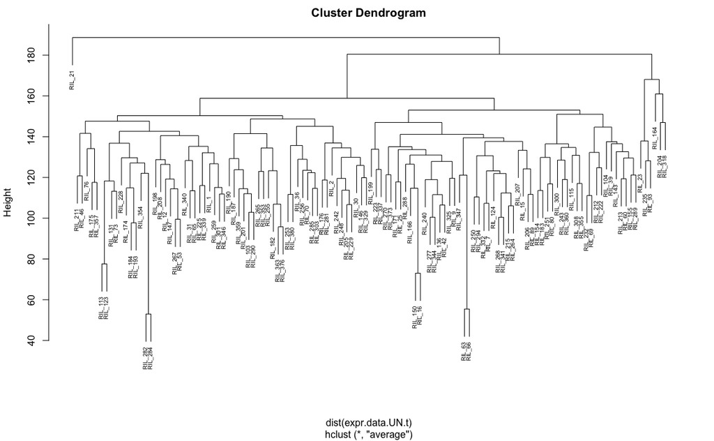

```r
sampleTREE.UN <- hclust(dist(expr.data.UN.t), method = "average")
plot(sampleTREE.UN,cex=.6)
```

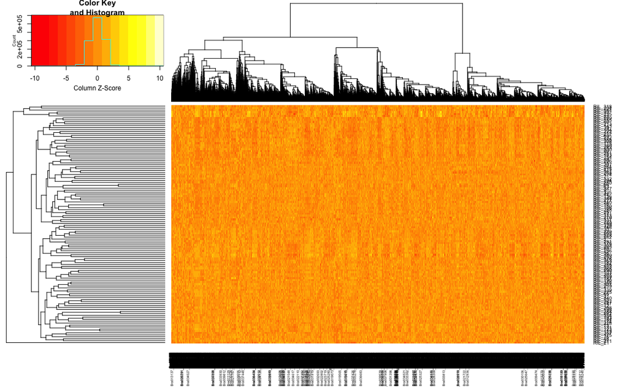

```r
heatmap.2(expr.data.UN.t,Rowv=as.dendrogram(sampleTREE.UN), scale="col", trace="none")
```

So a few samples are different but they don’t seem crazy different; leave them in for now.

Soft thresholding

```r
powers <- c(c(1:10), seq(from = 12, to=20, by=2))
sft <- pickSoftThreshold(expr.data.UN.t, powerVector = powers, verbose = 5,networkType = "signed hybrid")
```

```
pickSoftThreshold: will use block size 4473.
 pickSoftThreshold: calculating connectivity for given powers...
   ..working on genes 1 through 4473 of 10000
   ..working on genes 4474 through 8946 of 10000
   ..working on genes 8947 through 10000 of 10000
   Power SFT.R.sq  slope truncated.R.sq mean.k. median.k. max.k.
1      1    0.224 -0.603          0.623  997.00  903.0000 2110.0
2      2    0.899 -1.160          0.934  352.00  257.0000 1190.0
3      3    0.951 -1.290          0.955  167.00   91.3000  812.0
4      4    0.961 -1.320          0.963   93.90   39.5000  602.0
5      5    0.948 -1.340          0.949   58.70   20.1000  468.0
6      6    0.943 -1.350          0.943   39.40   11.0000  376.0
7      7    0.948 -1.350          0.948   27.90    6.4800  308.0
8      8    0.951 -1.350          0.952   20.50    4.0500  257.0
9      9    0.946 -1.350          0.944   15.50    2.6400  217.0
10    10    0.956 -1.330          0.954   12.00    1.7600  186.0
11    12    0.952 -1.330          0.953    7.65    0.8460  142.0
12    14    0.954 -1.330          0.957    5.17    0.4360  112.0
13    16    0.947 -1.330          0.951    3.65    0.2330   90.6
14    18    0.951 -1.320          0.957    2.67    0.1290   74.3
15    20    0.952 -1.310          0.961    2.01    0.0723   61.8
```

```r
sizeGrWindow(9, 5)
par(mfrow = c(1,2))
cex1 <- 0.9
# Scale-free topology fit index as a function of the soft-thresholding power
plot(sft$fitIndices[,1], -sign(sft$fitIndices[,3])*sft$fitIndices[,2],
     xlab="Soft Threshold (power)",ylab="Scale Free Topology Model Fit,signed R^2",type="n",
     main = paste("Scale independence"))
text(sft$fitIndices[,1], -sign(sft$fitIndices[,3])*sft$fitIndices[,2],
     labels=powers,cex=cex1,col="red")
```

```r
# this line corresponds to using an R^2 cut-off of h
abline(h=0.90,col="red")
# Mean connectivity as a function of the soft-thresholding power
plot(sft$fitIndices[,1], sft$fitIndices[,5],
     xlab="Soft Threshold (power)",ylab="Mean Connectivity", type="n",
     main = paste("Mean connectivity"))
```

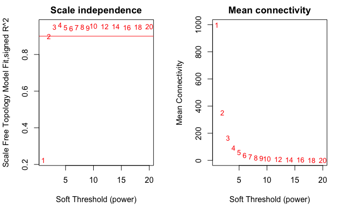

```r
text(sft$fitIndices[,1], sft$fitIndices[,5], labels=powers, cex=cex1,col="red")
```

choose 5

```r
softPower <- 5
adjacency <- adjacency(expr.data.UN.t, power = softPower, type = "signed hybrid")
# Turn adjacency into topological overlap
TOM <- TOMsimilarity(adjacency);
dissTOM <- 1-TOM
```

```r
# Call the hierarchical clustering function
geneTree <- hclust(as.dist(dissTOM), method = "average")
# Plot the resulting clustering tree (dendrogram)
sizeGrWindow(12,9)
plot(geneTree, xlab="", sub="", main = "Gene clustering on TOM-based dissimilarity",
     labels = FALSE, hang = 0.04)
```

[output not shown]

define modules

```r
# We like large modules, so we set the minimum module size relatively high:
minModuleSize <- 30;
# Module identification using dynamic tree cut:
dynamicMods <- cutreeDynamic(dendro = geneTree, distM = dissTOM,
                             deepSplit <- 2, pamRespectsDendro = FALSE,
                             minClusterSize = minModuleSize);
table(dynamicMods)
```

[output not shown]

```r
# Convert numeric lables into colors
dynamicColors = labels2colors(dynamicMods)
table(dynamicColors)
# Plot the dendrogram and colors underneath
sizeGrWindow(8,6)
plotDendroAndColors(geneTree, dynamicColors, "Dynamic Tree Cut",
                    dendroLabels = FALSE, hang = 0.03,
                    addGuide = TRUE, guideHang = 0.05,
                    main = "Gene dendrogram and module colors")
```

[output not shown]

merge similar modules

```r
# Calculate eigengenes
MEList <- moduleEigengenes(expr.data.UN.t, colors = dynamicColors)
MEs <- MEList$eigengenes
# Calculate dissimilarity of module eigengenes
MEDiss <- 1-cor(MEs);
# Cluster module eigengenes
METree <- hclust(as.dist(MEDiss), method = "average");
# Plot the result
sizeGrWindow(7, 6)
plot(METree, main = "Clustering of module eigengenes",
     xlab = "", sub = "")
```

[output not shown]

merge with correlation > 0.8

```r
MEDissThres = 0.2
# Plot the cut line into the dendrogram
plot(METree, main = "Clustering of module eigengenes",
     xlab = "", sub = "")
abline(h=MEDissThres, col = "red")
# Call an automatic merging function
merge = mergeCloseModules(expr.data.UN.t, dynamicColors, cutHeight = MEDissThres, verbose = 3)
# The merged module colors
mergedColors = merge$colors
# Eigengenes of the new merged modules:
mergedMEs = merge$newMEs
```

[output not shown]

compare pre and post merge

```r
sizeGrWindow(12, 9)
#pdf(file = "Plots/geneDendro-3.pdf", wi = 9, he = 6)
plotDendroAndColors(geneTree, cbind(dynamicColors, mergedColors),
                    c("Dynamic Tree Cut", "Merged dynamic"),
                    dendroLabels = FALSE, hang = 0.03,
                    addGuide = TRUE, guideHang = 0.05)
#dev.off()
```

[output not shown]

```r
# Rename to moduleColors
moduleColors = mergedColors
# Construct numerical labels corresponding to the colors
colorOrder = c("grey", standardColors(50));
moduleLabels = match(moduleColors, colorOrder)-1;
MEs = mergedMEs
table(merge$colors)
length(table(merge$colors))
median(table(merge$colors))
```

```r
head(MEs)
dim(MEs)
dim(blups.UN)
rownames(expr.data.UN.t)
rownames(MEs)
rownames(MEs) <- rownames(expr.data.UN.t)
head(blups.UN)
```

```r
ME.blups <- merge(blups.UN,MEs,by.x=1.,by.y=0)
head(ME.blups)
```

```r
blups.cor <- cor(ME.blups[,2:6],ME.blups[,7:66])
max(blups.cor)
blups.cor
```

[output not shown]

```r
blups.cor.P <- corPvalueStudent(blups.cor,nrow(expr.data.UN.t)) %>%
  p.adjust() %>% #using "holm" method.  For relaxed stringency could use "fdr"
  matrix(nrow=nrow(blups.cor),
         dimnames = dimnames(blups.cor))

sum(blups.cor.P < 0.05)

blups.cor.sig <- blups.cor
blups.cor.sig[blups.cor.P>0.05] <- NA
blups.cor.sig

p.asterisk <- ifelse(blups.cor.P < 0.05, "*","")
```

plot it

```r
# Will display correlations and their p-values
par(mar = c(8, 5, 3, 3));
# Display the correlation values within a heatmap plot
labeledHeatmap(Matrix = blups.cor,
               yLabels = names(blups.UN)[-1],
               xLabels = names(MEs),
               xSymbols = names(MEs),
               colorLabels = FALSE,
               colors = blueWhiteRed(50),
               textMatrix = p.asterisk,
               setStdMargins = FALSE,
               #cex.text = 0.5,
               zlim = c(-1,1),
               main = "UN Module-trait relationships")

pdf("Module-trait_heatmap_UN.pdf",height = 8,width = 12)
par(mar = c(8, 5, 3, 3));
# Display the correlation values within a heatmap plot
labeledHeatmap(Matrix = blups.cor,
               yLabels = names(blups.UN)[-1],
               xLabels = names(MEs),
               xSymbols = names(MEs),
               colorLabels = FALSE,
               colors = blueWhiteRed(50),
               textMatrix = p.asterisk,
               setStdMargins = FALSE,
               #cex.text = 0.5,
               zlim = c(-1,1),
               main = paste("UN Module-trait relationships"))
dev.off()
```

[output not shown]

Arbitrary, but let’s take the max and min for each trait (so long as they are significant)

```r
blups.cor.5 <- blups.cor.sig

cor.top <- t(apply(blups.cor.5,1,function(x) {
  maxx = max(x,na.rm=TRUE)
  minx = min(x,na.rm=TRUE)
  ifelse(x == maxx | x == minx, x, NA)
}
))


cor.top <- cor.top[,apply(cor.top,2,function(x) !all(is.na(x)))]
cor.top
write.csv(cor.top,"Eigen_trait_cor_UN_.5_threshold.csv")
```

write the Eigen genes

```r
head(MEs[,colnames(cor.top)])
write.csv(MEs[,colnames(cor.top)],"Top_Eigen_genes_UN.csv")
```

write all Eigen genes

```r
write.csv(MEs,"All_Eigen_genes_UN.csv")
```

save WGCNA info

```r
save(annotation,blups.cor,blups.cor.5,blups.cor.P,blups.cor.sig,moduleColors,MEs,merge,expr.data.UN.t,
     file="~/Box Sync/BrapaNetworks/WGCNA_UN.Rdata")
```

## GO enrichment for each signficant cluster

```r
load("~/Box Sync/BrapaNetworks/WGCNA_UN.Rdata")
module_genes <- tibble(GeneID=colnames(expr.data.UN.t), module=moduleColors)
module_genes
```

Get GO list and gene lengths

```r
wget http://www.g3journal.org/content/suppl/2014/08/12/g3.114.012526.DC1/FileS11.txt
wget http://jnmaloof.github.io/BIS180L_web/data/Brapa_CDS_lengths.txt
```

```r
library(goseq)
library(tidyverse)
library(stringr)
```

Format data for GOseq

```r
go.terms <- read.delim("FileS11.txt",header=FALSE,as.is=TRUE)
head(go.terms)
names(go.terms) <- c("GeneID","GO")
summary(go.terms)

gene.lengths <- read.table("Brapa_CDS_lengths.txt",as.is=TRUE)
head(gene.lengths)
summary(gene.lengths)

#For this analysis the "Universe" will be all 10000 genes used as input to WGCNA, and the test set will be each module that showed a significant correlation with a FVT blup.

#we need to reduce the gene.length data to only contain entries for those genes in our universe.  We also need this as a vector
gene.lengths.module <- gene.lengths %>%
  semi_join(module_genes,by="GeneID")

gene.lengths.vector <- as.vector(gene.lengths.module$Length)
names(gene.lengths.vector) <- gene.lengths.module$GeneID

#Do the reverse to make sure everything matches up (it seems that we don't have length info for some genes?)

module_genes <- semi_join(module_genes,gene.lengths.module)
```

Format go.terms for goseq. We want them in list format, and we need to separate the terms into separate elements.

```r
go.list <- strsplit(go.terms$GO,split=",")
names(go.list) <- go.terms$GeneID
head(go.list)
```

Now we will loop through each significant module

First, get the sig modules

```r
sig.modules <- colnames(blups.cor.P) %>%
  magrittr::extract(apply(blups.cor.P,2,function(x) any(x < 0.05))) %>%
  str_replace("ME","")
sig.modules
```

Format module data for goseq. We need a vector for each gene with 1 indicating module membership and 0 indicating not in module

```r
file.remove("~/Box Sync/BrapaNetworks/_Figures_Tables_For_Paper/SupTable_JM5_WGCNA_UN_GO.csv")

GO.results <- lapply(sig.modules, function(module) {
  module01 <- module_genes$module %>% str_detect(module) %>% as.numeric()
  names(module01) <- module_genes$GeneID

  #determines if there is bias due to gene length.
  nullp.result.tmp <- nullp(DEgenes = module01,bias.data = gene.lengths.vector,plot.fit = FALSE)

  #calculate p-values for each GO term
  GO.out.tmp <- goseq(pwf = nullp.result.tmp,gene2cat = go.list,test.cats=("GO:BP"))

  #Keep CC and BP
  GO.out.tmp <- GO.out.tmp[GO.out.tmp$ontology=="BP" | GO.out.tmp$ontology=="CC",]

  #Calculate FDR
  GO.out.tmp <- GO.out.tmp %>% as.tibble() %>%
    mutate(FDR=p.adjust(over_represented_pvalue, method = "fdr"),module=module) %>%
    filter(FDR < 0.05) %>%
    select(module,term,ontology,FDR,over_represented_pvalue,everything())

  write_csv(GO.out.tmp,path = "~/Box Sync/BrapaNetworks/_Figures_Tables_For_Paper/SupTable_JM5_WGCNA_UN_GO.csv",append = TRUE)

  GO.out.tmp
})
names(GO.results) <- sig.modules
```

```r
GO.results
```

[output not shown]